# Danish Kings

Laura Emilie Hollænder Jensen

2026-03-13

The task here is to load your Danish Monarchs csv into R using the `tidyverse` toolkit, calculate and explore the kings’ duration of reign with pipes `%>%` in `dplyr` and plot it over time.

## Load the kings

Make sure to first create an `.Rproj` workspace with a `data/` folder where you place either your own dataset or the provided `kings.csv` dataset.

1. Look at the dataset that are you loading and check what its columns are separated by? (hint: open it in plain text editor to see) List what is the separator. ANSWER: In Danish_kings.csv, the separator is “;”.
2. Create a `kings` object in R with the different functions below and inspect the different outputs.
- `read.csv()`
- `read_csv()`
- `read.csv2()`
- `read_csv2()` ANSWER: In the code chunks below, I will load a kings-object using four different functions. I will use the function ‘glimpse()’ to inspect the output.

```r
library(tidyverse)
library(dplyr)
# FILL IN THE CODE BELOW and review the outputs
kings1 <- read.csv("data/Danish_kings.csv")
glimpse(kings1)
```

```
## Rows: 55
## Columns: 1
## $ Name.Born.Dead.Reign_start.Reign_end <chr> "Gorm_den_Gamle;913;958;936;958",…
```

```r
class(kings1)
```

```
## [1] "data.frame"
```

```r
ncol(kings1)
```

```
## [1] 1
```

```r
kings2 <- read_csv("data/Danish_kings.csv")
glimpse(kings2)
```

```
## Rows: 55
## Columns: 1
## $ `Name;Born;Dead;Reign_start;Reign_end` <chr> "Gorm_den_Gamle;913;958;936;958…
```

```r
class(kings2)
```

```
## [1] "spec_tbl_df" "tbl_df"      "tbl"         "data.frame"
```

```r
ncol(kings2)
```

```
## [1] 1
```

```r
kings3 <- read.csv2("data/Danish_kings.csv")
glimpse(kings3)
```

```
## Rows: 55
## Columns: 5
## $ Name        <chr> "Gorm_den_Gamle", "Harald_1._Blaatand ", "Svend_1._Tveskae…
## $ Born        <int> 913, 958, 987, NA, 995, 1020, 1024, 1076, 1040, 1042, 1050…
## $ Dead        <int> 958, 987, 1014, 1018, 1035, 1042, 1047, 1074, 1080, 1086, …
## $ Reign_start <int> 936, 958, 987, 1014, 1018, 1035, 1042, 1047, 1074, 1080, 1…
## $ Reign_end   <int> 958, 987, 1014, 1018, 1035, 1042, 1047, 1074, 1080, 1086, …
```

```r
class(kings3)
```

```
## [1] "data.frame"
```

```r
ncol(kings3)
```

```
## [1] 5
```

```r
kings4 <- read_csv2( "data/Danish_kings.csv")
```

```
## ℹ Using "','" as decimal and "'.'" as grouping mark. Use `read_delim()` for more control.
```

```r
glimpse(kings4)
```

```
## Rows: 55
## Columns: 5
## $ Name        <chr> "Gorm_den_Gamle", "Harald_1._Blaatand", "Svend_1._Tveskaeg…
## $ Born        <dbl> 913, 958, 987, NA, 995, 1020, 1024, 1076, 1040, 1042, 1050…
## $ Dead        <dbl> 958, 987, 1014, 1018, 1035, 1042, 1047, 1074, 1080, 1086, …
## $ Reign_start <dbl> 936, 958, 987, 1014, 1018, 1035, 1042, 1047, 1074, 1080, 1…
## $ Reign_end   <dbl> 958, 987, 1014, 1018, 1035, 1042, 1047, 1074, 1080, 1086, …
```

```r
class(kings4)
```

```
## [1] "spec_tbl_df" "tbl_df"      "tbl"         "data.frame"
```

```r
ncol(kings4)
```

```
## [1] 5
```

Answer: 1. Which of these functions is a `tidyverse` function? Read data with it below into a `kings` object

ANSWER: The functions read_csv and read_csv2 are tidyverse functions.

2. What is the result of running `class()` on the `kings` object created with a tidyverse function.

ANSWER: Running ‘class()’ on the ‘kings’ object returns this result: “spec_tbl_df” “tbl_df” “tbl” “data.frame” This tells me that the ‘kings’ object is a tibble.

3. How many columns does the object have when created with these different functions?

ANSWER: The objects created using read.csv and read_csv have only one columns. The objects created using read.csv2 and read_csv2 have 5 columns.

4. Show the dataset so that we can see how R interprets each column

ANSWER: The ‘glimpse()’ function lets me inspect the dataset and shows me how R interprets the data. The ‘Name’ column is interpreted as the class character. read.csv2 interprets the columns ‘Born’, ‘Dead’, ‘Reign_start’ and ‘Reign_end’ as the type “integer”. read_csv2 interprets the columns ‘Born’, ‘Dead’, ‘Reign_start’ and ‘Reign_end’ as the type “double”.

```r
# In this code chunk, I am using the function 'read_csv2' to create the object
# that I will perform calculations on. I will call it 'kings'.

kings <- read_csv2("data/Danish_kings.csv")
```

```
## ℹ Using "','" as decimal and "'.'" as grouping mark. Use `read_delim()` for more control.
```

```r
glimpse(kings)
```

```
## Rows: 55
## Columns: 5
## $ Name        <chr> "Gorm_den_Gamle", "Harald_1._Blaatand", "Svend_1._Tveskaeg…
## $ Born        <dbl> 913, 958, 987, NA, 995, 1020, 1024, 1076, 1040, 1042, 1050…
## $ Dead        <dbl> 958, 987, 1014, 1018, 1035, 1042, 1047, 1074, 1080, 1086, …
## $ Reign_start <dbl> 936, 958, 987, 1014, 1018, 1035, 1042, 1047, 1074, 1080, 1…
## $ Reign_end   <dbl> 958, 987, 1014, 1018, 1035, 1042, 1047, 1074, 1080, 1086, …
```

```r
class(kings)
```

```
## [1] "spec_tbl_df" "tbl_df"      "tbl"         "data.frame"
```

```r
ncol(kings)
```

```
## [1] 5
```

```r
head(kings)
```

```
## # A tibble: 6 × 5
##   Name                Born  Dead Reign_start Reign_end
##   <chr>              <dbl> <dbl>       <dbl>     <dbl>
## 1 Gorm_den_Gamle       913   958         936       958
## 2 Harald_1._Blaatand   958   987         958       987
## 3 Svend_1._Tveskaeg    987  1014         987      1014
## 4 Harald _2.            NA  1018        1014      1018
## 5 Knud_1._den_Store    995  1035        1018      1035
## 6 Hardeknud           1020  1042        1035      1042
```

```r
# The function ncol() run on 'kings' returns the number 5.
```

## Calculate the duration of reign for all the kings in your table

You can calculate the duration of reign in years with `mutate` function by subtracting the equivalents of your `startReign` from `endReign` columns and writing the result to a new column called `duration`. But first you need to check a few things:

- Is your data messy? Fix it before re-importing to R
- Do your start and end of reign columns contain NAs? Choose the right strategy to deal with them: `na.omit()`, `na.rm=TRUE`, `!is.na()`

Create a new column called `duration` in the kings dataset, utilizing the `mutate()` function from tidyverse. Check with your group to brainstorm the options.

```r
# YOUR CODE
kings <- kings %>%
  mutate(Duration = Reign_end - Reign_start)
glimpse(kings)
```

```
## Rows: 55
## Columns: 6
## $ Name        <chr> "Gorm_den_Gamle", "Harald_1._Blaatand", "Svend_1._Tveskaeg…
## $ Born        <dbl> 913, 958, 987, NA, 995, 1020, 1024, 1076, 1040, 1042, 1050…
## $ Dead        <dbl> 958, 987, 1014, 1018, 1035, 1042, 1047, 1074, 1080, 1086, …
## $ Reign_start <dbl> 936, 958, 987, 1014, 1018, 1035, 1042, 1047, 1074, 1080, 1…
## $ Reign_end   <dbl> 958, 987, 1014, 1018, 1035, 1042, 1047, 1074, 1080, 1086, …
## $ Duration    <dbl> 22, 29, 27, 4, 17, 7, 5, 27, 6, 6, 9, 8, 30, 3, 9, 11, 11,…
```

## Calculate the average duration of reign for all rulers

Do you remember how to calculate an average on a vector object? If not, review the last two lessons and remember that a column is basically a vector. So you need to subset your `kings` dataset to the `duration` column. If you subset it as a vector you can calculate average on it with `mean()` base-R function. If you subset it as a tibble, you can calculate average on it with `summarize()` tidyverse function. Try both ways!

- You first need to know how to select the relevant `duration` column. What are your options?
- Is your selected `duration` column a tibble or a vector? The `mean()` function can only be run on a vector. The `summarize()` function works on a tibble.
- Are you getting an error that there are characters in your column? Coerce your data to numbers with `as.numeric()`.
- Remember to handle NAs: `mean(X, na.rm=TRUE)`

```r
# Base R version:
# First way: Extracting a column as a vector using $.
mean_duration <- mean(kings$Duration, na.rm = TRUE)
mean_duration
```

```
## [1] 20.2963
```

```r
# Returns a value of 20.2963.

# Tidyverse version:
tidy_mean_duration <- kings %>%
  summarise(mean(Duration, na.rm = TRUE))
tidy_mean_duration
```

```
## # A tibble: 1 × 1
##   `mean(Duration, na.rm = TRUE)`
##                            <dbl>
## 1                           20.3
```

```r
# Returns a tibble containing the mean.
```

## How many and which kings enjoyed a longer-than-average duration of reign?

You have calculated the average duration above. Use it now to `filter()` the `duration` column in `kings` dataset. Display the result and also count the resulting rows with `count()`

ANSWER: 25 kings enjoyed a longer-than-average duration of reign.

```r
kings %>%
  filter(Duration > tidy_mean_duration) %>%
  select(Name, Duration)
```

```
## # A tibble: 55 × 2
##    Name                Duration
##    <chr>                  <dbl>
##  1 Gorm_den_Gamle            22
##  2 Harald_1._Blaatand        29
##  3 Svend_1._Tveskaeg         27
##  4 Harald _2.                 4
##  5 Knud_1._den_Store         17
##  6 Hardeknud                  7
##  7 Magnus_den_Gode            5
##  8 Svend_2._Estridsen        27
##  9 Harald_3._Hen              6
## 10 Knud_2._den_Hellige        6
## # ℹ 45 more rows
```

```r
# This does not work and prints a warning message, because
# tidy_mean_duration is a tibble i.e. a one column matrix.
# Let's try it again with the mean I calculated using base R, 'mean_duration',
# which is a value and not a tibble.

kings %>%
  filter(Duration > mean_duration) %>%
  select(Name, Duration)
```

```
## # A tibble: 25 × 2
##    Name                 Duration
##    <chr>                   <dbl>
##  1 Gorm_den_Gamle             22
##  2 Harald_1._Blaatand         29
##  3 Svend_1._Tveskaeg          27
##  4 Svend_2._Estridsen         27
##  5 Niels                      30
##  6 Valdemar_1.                36
##  7 Valdemar_2._Sejr           39
##  8 Erik_5._Klipping           27
##  9 Erik_6._Menved             33
## 10 Valdemar_4._Atterdag       35
## # ℹ 15 more rows
```

```r
# This works! Now, let's count them.

kings %>%
  filter(Duration > mean_duration) %>%
  select(Name, Duration) %>%
  count()
```

```
## # A tibble: 1 × 1
##       n
##   <int>
## 1    25
```

```r
# The 'count()' function returns a tibble containing just one integer: 25.
# That means that 25 kings enjoyed a longer-than-average duration of reign.

# We can also make an object containing only the longer-than-average reigning
# monarchs.
above_average_kings <- kings %>%
  filter(Duration > mean_duration) %>%
  select(Name, Duration)
  view(above_average_kings)
```

## How many days did the three longest-ruling monarchs rule?

```r
# Sorting in descending order.
kings %>%
  select(Name, Duration) %>%
  arrange(desc(Duration))
```

```
## # A tibble: 55 × 2
##    Name                 Duration
##    <chr>                   <dbl>
##  1 Christian_4.               60
##  2 Margrethe_2.               52
##  3 Erik_7._af_Pommern         43
##  4 Christian_9.               43
##  5 Christian_7.               42
##  6 Valdemar_2._Sejr           39
##  7 Valdemar_1.                36
##  8 Valdemar_4._Atterdag       35
##  9 Christian_10.              35
## 10 Erik_6._Menved             33
## # ℹ 45 more rows
```

```r
# Selecting only the three longest-ruling monarchs.
top_kings <- kings %>%
  arrange(desc(Duration)) %>%
  slice(1:3)

# Using mutate() to create a 'Days' column.
top_kings <- top_kings %>%
  mutate(Days = Duration * 365)

# BONUS: consider the transition year (with 366 days) in your calculation!
top_kings <- top_kings %>%
  mutate(
    Leap_years = Duration %/% 4,
    Days_accounting_for_leap_years = Duration * 365 + Leap_years)
glimpse(top_kings)
```

```
## Rows: 3
## Columns: 9
## $ Name                           <chr> "Christian_4.", "Margrethe_2.", "Erik_7…
## $ Born                           <dbl> 1577, 1940, 1382
## $ Dead                           <dbl> 1648, NA, 1439
## $ Reign_start                    <dbl> 1588, 1972, 1396
## $ Reign_end                      <dbl> 1648, 2024, 1439
## $ Duration                       <dbl> 60, 52, 43
## $ Days                           <dbl> 21900, 18980, 15695
## $ Leap_years                     <dbl> 15, 13, 10
## $ Days_accounting_for_leap_years <dbl> 21915, 18993, 15705
```

## Challenge: Plot the kings’ duration of reign through time

What is the long-term trend in the duration of reign among Danish monarchs? How does it relate to the historical violence trends ? ANSWER: The long-term trend in the duration of reign among Danish monarchs is that duration of reign increases through history.

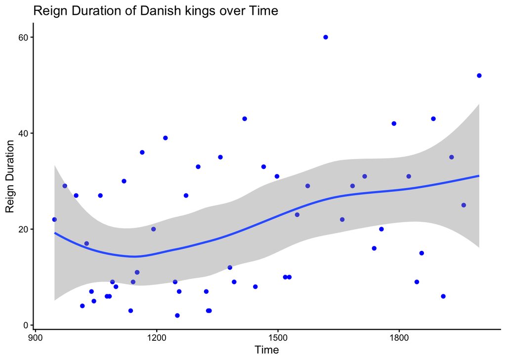

```r
kings %>%
  mutate(Duration = Reign_end - Reign_start) %>%
  mutate(Midyear = Reign_end - Duration/2) %>%
  ggplot(aes (x = Midyear, y = Duration)) +
  geom_point(col = "blue") +
  geom_smooth() +
  theme_classic() +
  labs(title = "Reign Duration of Danish kings over Time",
       x = "Time",
       y = "Reign Duration")
```